# Python语言快速入门

使用空格缩进划分代码块，而非使用大括号和关键词

## Python的安装与简单使用

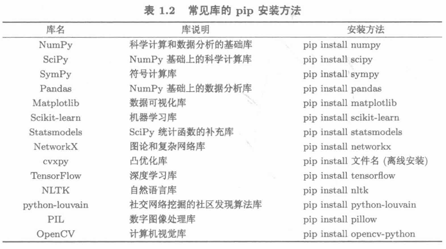

```python
print("hello world!!!")
```

```
hello world!!!
```

## Python基础知识

### 基本数据处理

变量命名规则：

- 第一个字符必须是英文字母，下划线“_”或中文，其余字符可以搭配其他的大小写英文字母，数字，下划线或中文
- 不能使用Python内置的关键字
- 区分大小写字母

**变量名 = 数据**

例如：

```python
score=100

n=m=20

a,b,c,=80,60,40

a=10;b=20
```

#### 数值数据类型

整数 浮点数

#### 布尔数据类型

Ture False

#### 字符串数据类型

一个字符串可以使用单引号，双引号

三引号通常用于多行文本信息

```python
str1="hello world"

str2='python'

str3='''hello!

world!'''

print(str1)
print(str2)
print(str3)
# print默认结尾是换行符\n，把end改成空字符串或空格就能同行
print(str1, end=" ")
print(str2, end=" ")
# 一个 print 多参数输出
print(str1, str2, str3)
```

```
hello world
python
hello!

world!
hello world python hello world python hello!

world!
```

### 输出print和输入input

#### 输出print（）函数

```python
print("四书五经")
print("《大学》","《中庸》", "《论语》", "《孟子》", sep='、')
print("《大学》","《中庸》", "《论语》", "《孟子》")
print("《大学》","《中庸》", "《论语》", "《孟子》", end='    ')
print("《易经》","《诗经》", "《尚书》", "《礼记》", "《春秋》")
```

```
四书五经
《大学》、《中庸》、《论语》、《孟子》
《大学》 《中庸》 《论语》 《孟子》
《大学》 《中庸》 《论语》 《孟子》    《易经》 《诗经》 《尚书》 《礼记》 《春秋》
```

print支持格式化功能，由“%”字符和后面的格式化字符串控制

%s %f %d和c语言一样

```python
name="张三";age=20
print("%s的年龄是%d"%(name, age))
print("{}的年龄是{}".format(name,age))
```

```
张三的年龄是20
张三的年龄是20
```

对齐效果(加负号是左对齐)

```python
str="hi"
print("%7s"%str)
num=123
print("%7d"%num)
num=123.456
print("%7.2f"%num)
```

```
     hi
    123
 123.46
```

#### 输出转义字符

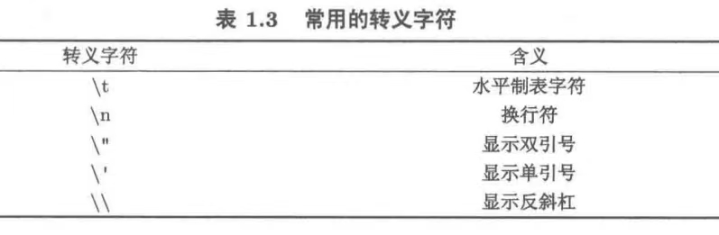

#### 输入input（）函数

input输入的是字符串，用int()或eval()变成整数，用float()变成浮点数

```python
height=input("请输入你的身高：")
print(height)
```

```
185
```

```python
pi=3.1415926
r=float(input("请输入圆的半径："))
print("圆的周长是：%.7f" %(2*pi*r))
```

```
圆的周长是：12.5663704
```

四种进制格式输出方式

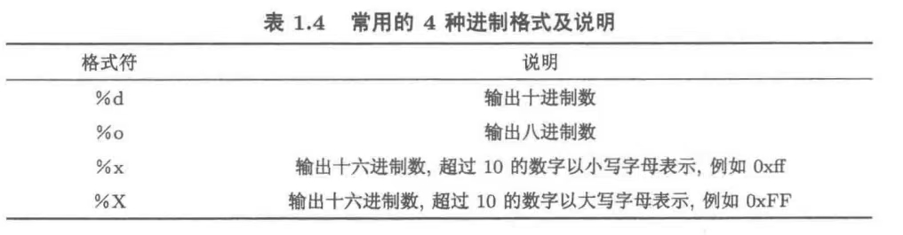

### 运算符与表达式

#### 算术运算符

```python
x1=58+32
x2=89-28
x3=3*12
x4=125/7    #正常除法，带小数
x5=125//7   #整除
x6=4**3     #幂次
x7=46%5     #取余数
print(x1,x2,x3,x4,x5,x6,x7,sep=" ")
```

```
90 61 36 17.857142857142858 17 64 1
```

#### 复合赋值运算符

跟c语言一样

x+=1

x-=2

#### 关系运算符

成立返回true，不成立返回false

跟c语言一样

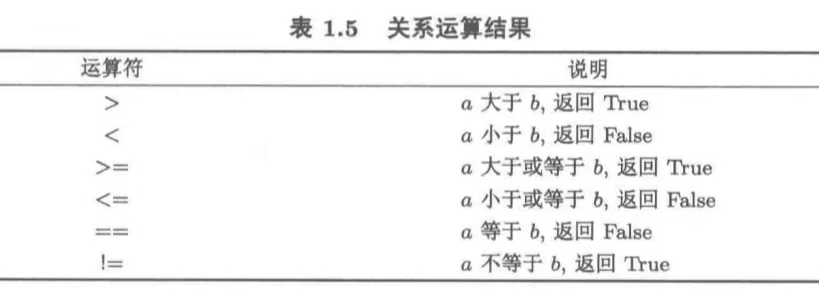

#### 逻辑运算符

not，and，or

```python
print(100>2)and(52>41)
total=124
value=(total%4==0)and(total%3==0)
print(value)
```

```
True
False
```

#### 位运算符

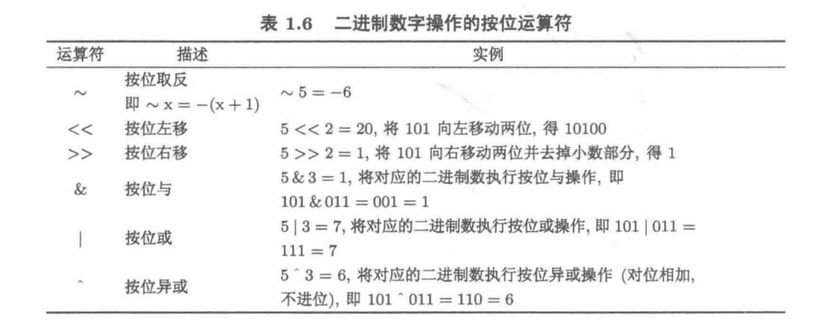

转二进制函数bin（）

```python
print(bin(10))
```

```
0b1010
```

### 流程控制

3种流程控制结构，即if，for，while

#### if语句

if，elif，else

注意if后要加冒号：，语句要缩进

```python
a,b=eval(input("请输入两个整数："))
if a>=b:
    print("最大的数为:%d"%a)
else:
    print("最大的数为:%d"%b)
```

[output not shown]

#### for循环

配合range（）函数使用，返回一个等差数列的可迭代对象，初始值默认为0，步长默认为1，要转化成列表

```python
print(list(range(5)))
print(list(range(1,6)))
print(list(range(1,10,2)))
```

```
[0, 1, 2, 3, 4]
[1, 2, 3, 4, 5]
[1, 3, 5, 7, 9]
```

```python
sum=0
number=eval(input("请输入一个整数："))
print("从小到大排列输出数字：")
for i in range(1,number+1):
    sum+=i
    print("%d"%i,end="")
    if i<number:
        print("+",end="")
    else :
        print("=",end="")
print("%d"%sum)
print("从大到小排列输出数字：")
for i in range(number,0,-1):
    print("%d"%i,end="")
    if i>1:
        print("+",end="")
    else :
        print("=",end="")
print("%d"%sum)
```

```
从小到大排列输出数字：
1+2+3+4+5+6+7=28
从大到小排列输出数字：
7+6+5+4+3+2+1=28
```

#### while循环

例：求$ \sin x = \sum_{n=0}^{\infty} \frac{(-1)^n x^{2n+1}}{(2n+1)!} = x - \frac{x^3}{3!} + \frac{x^5}{5!} - \frac{x^7}{7!} + \cdots $直到最后一项小于$10^{-6}$时停止计算

```python
from math import *
n=0;x1=float(input("请输入一个角度"))
x=radians(x1)
s=a=x
while abs(a)>1e-6:
    a*=(-1)*x*x/(2*n+3)/(2*n+2)
    n+=1
    s+=a
print("x={},sin(x)={}".format(x1,s))
```

```
x=32.0,sin(x)=0.529919264274441
```

## 复合数据类型

列表，元组，集合，字典

列表，元组，字符串有序，称为序列，可以用索引访问

集合，字典无顺序

### list列表

#### 索引

正向索引，负向索引，切片索引，无限索引

```python
a=["张三","男","23","江苏","硕士","已婚",["身高172","体重70"]]
print(a[0])
print(a[-1])
print(a[-1][1])
print(a[-3:])
print(a[:3])
print(a[::2])
print(a[0:-1])
```

```
张三
['身高172', '体重70']
体重70
['硕士', '已婚', ['身高172', '体重70']]
['张三', '男', '23']
['张三', '23', '硕士', ['身高172', '体重70']]
['张三', '男', '23', '江苏', '硕士', '已婚']
```

#### 列表元素的增加

append，extend，insert

```python
a=[1,2,3]
a.append(4)
print(a)
a.extend([3,2,1])
print(a)
a.insert(0,-1)
print(a)
```

```
[1, 2, 3, 4]
[1, 2, 3, 4, 3, 2, 1]
[-1, 1, 2, 3, 4, 3, 2, 1]
```

#### 列表元素的删除

pop,remove,clear

```python
a=[10,20,30,5,8,5,8,6,6]
a.pop() #尾删
print(a)
a.pop(2)    #按索引删除
print(a)
a.remove(8);a.remove(8)     #从左删第一个
print(a)
a.clear()
print(a)
```

```
[10, 20, 30, 5, 8, 5, 8, 6]
[10, 20, 5, 8, 5, 8, 6]
[10, 20, 5, 5, 6]
[]
```

#### 列表的常用操作

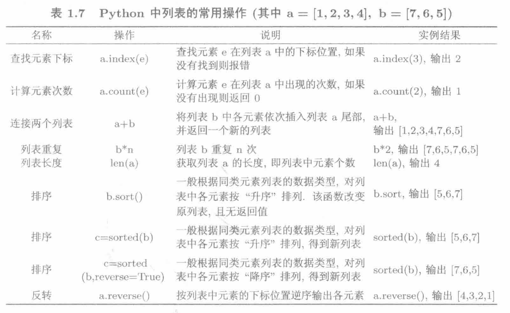

### tuple元组，dict字典，set集合

#### tuple元组

不能被修改的列表，可以只用逗号分隔，或用小括号，只有count，index

```python
my_tuple=(1,2,3,4,5)
print(my_tuple)
tuple1=1,2,3,4,5
print(tuple1)
tuple2=1,
print(tuple2)
```

```
(1, 2, 3, 4, 5)
(1, 2, 3, 4, 5)
(1,)
```

#### dic字典

- 大括号，键值对，key：value
- 键要唯一
- 字典不再是序列，不能位置索引，只能键索引
- 可变
- 可以用dict（）函数先创建空字典

```python
d={"姓名":"张三","年龄":"33","子女":{"子":"张四","女":"张玲"}}
print(d)
print(d["年龄"])
d["年龄"]=35
print(d)
d["户籍"]="烟台"
print(d)
d.pop("子女")
print(d)
```

```
{'姓名': '张三', '年龄': '33', '子女': {'子': '张四', '女': '张玲'}}
33
{'姓名': '张三', '年龄': 35, '子女': {'子': '张四', '女': '张玲'}}
{'姓名': '张三', '年龄': 35, '子女': {'子': '张四', '女': '张玲'}, '户籍': '烟台'}
{'姓名': '张三', '年龄': 35, '户籍': '烟台'}
```

#### 集合

有互异性

##### 集合的创建

- 大括号和逗号分割
- set（）函数，将字符串，列表，元组转换成集合类型的数据

```python
a=set("abcde")
print(a)
b=[1,2,2,2,3,5,6,6]
c=set(b)    #转化为集合，去除重复元素
print(list(c))
```

```
{'e', 'a', 'b', 'c', 'd'}
[1, 2, 3, 5, 6]
```

##### 集合的常用方法

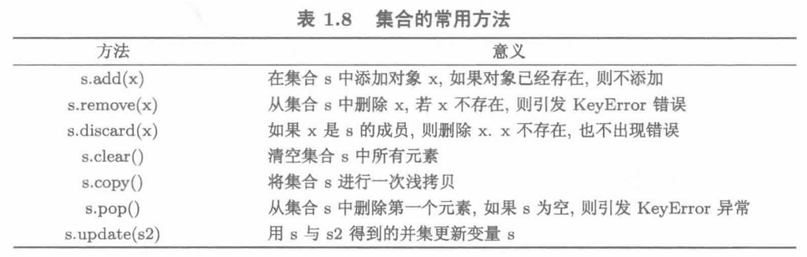

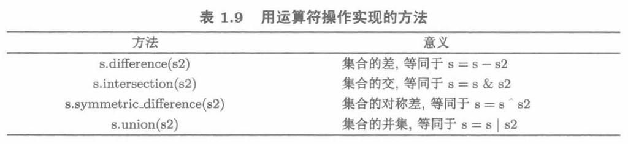

### 序列的一些实用操作

#### string字符串的实用操作

##### str()：将数值数据转化成字符串

##### len():字符串长度

##### count():字符子字符串的出现次数

##### eval():把字符串变成Python语句执行

##### find():返回子字符串的左端索引，没找到返回-1

##### rfind():从右往左查找

##### split():将字符串分割成序列，默认按空格分隔

```python
str1="I am a student"
list1=str1.split()
str2="1,2,3,4"
list2=str2.split(",")
print(list1,list2)
```

```
['I', 'am', 'a', 'student'] ['1', '2', '3', '4']
```

##### strip():去除字符串开头结尾的空格字符，lstrip():去除开头空格，rstrip():去除结尾空格

```python
str="    I am a student   "
print(str.strip())
```

```
I am a student
```

##### join():可认为是split()函数的逆方法

#### 几个序列操作函数

lambda函数，也称为匿名函数

例：$f(x,y) = |x| + y^3$

```python
f=lambda x,y:abs(x)+y**3
print(f(-3,2))
```

```
11
```

##### map()

调用格式map(func,*iterables)

map()接收一个函数func和一个列表，把func依次作用在列表的每个元素上，得到一个新列表

```python
a=map(lambda x:pow(x,2),[1,2,3,4])
# a=map(pow,range(6),[2 for b in range(6)])
print(list(a))
```

[output not shown]

##### reduce()

调用格式reduce(function,sequence[,initial])

function是有两个参数的函数,sequence是元组，列表，字典，字符串等可迭代的对象，initial是可选的初始值

```python
from functools import reduce
print(reduce(lambda x,y:x*y,range(1,6)))
print(reduce(lambda x,y:x+y,range(1,7)))
```

```
120
21
```

##### filter()

调用格式filter(function of None,iterable)

对使function返回true的元素经行过滤

```python
print(list(filter(lambda x:x%3==0,range(1,21))))
```

```
[3, 6, 9, 12, 15, 18]
```

##### zip()

将多个列表或元组的对应位置的元素组合为元组

```python
a=range(1,5)
b=range(5,9)
d=range(9,13)
c=zip(a,b)
print(list(c))
# *操作符将元组分为了两个独立的参数进行传递
print(list(zip(*zip(a,b,d))))
```

```
[(1, 5), (2, 6), (3, 7), (4, 8)]
[(1, 2, 3, 4), (5, 6, 7, 8), (9, 10, 11, 12)]
```

##### enumerate()

枚举

```python
a=[(1,5),(2,6),(3,7),(4,8)]
for b in enumerate(a):
    print(b)
```

```
(0, (1, 5))
(1, (2, 6))
(2, (3, 7))
(3, (4, 8))
```

#### 列表推导式和元组生成器推导式

##### 列表推导式

```python
b=[[0]*6 for i in range(4)]
print(b)
```

```
[[0, 0, 0, 0, 0, 0], [0, 0, 0, 0, 0, 0], [0, 0, 0, 0, 0, 0], [0, 0, 0, 0, 0, 0]]
```

##### 元组生成器推导式

```python
g=((i+1)**2 for i in range(6))
print(tuple(g))
```

```
(1, 4, 9, 16, 25, 36)
```

## 函数

内置函数，第三方函数，自定义函数

### 自定义函数语法

def functionName(formalParameters):

```
functionBody
```

用三引号注释来说明函数

函数体内容不可为空，用pass表示空语句

```python
from Pexl_5_1 import *
print(factorial(5))
```

```
120
```

#### 默认参数

赋了各自的初值

```python
def square_sum(n,p=2):
    result=sum([i**p for i in range(1,n+1)])
    return (n,p,result)
print("从1到%d的%d次方和为%d"%square_sum(10))
print("从1到%d的%d次方和为%d"%square_sum(10,3))
```

```
从1到10的2次方和为385
从1到10的3次方和为3025
```

#### 可变参数

不确定该给自定义函数传入多少个参数值,可变参数调用时自动组装为一个元祖

```python
def add(*args):
    print(args,end=" ")
    s=sum(args)
    return s
print("的和为",add(10,12,8,6))
```

```
(10, 12, 8, 6) 的和为 36
```

#### 关键字函数

关键字参数会把带参数名的参数值组装到一个字典中，键就是具体的实参名，值就是传入的参数值

```python
def person(name,age,**kw):
    print("name:",name,"age:",age,"other:",kw)

person("Michael",30)
person("Bob",35,cith="Beijing")
person("Adam",45,gender="M",job="Engineer")
```

```
name: Michael age: 30 other: {}
name: Bob age: 35 other: {'cith': 'Beijing'}
name: Adam age: 45 other: {'gender': 'M', 'job': 'Engineer'}
```

### 参数传递

#### 参数传递方式

- 传值：函数中对参数值的修改，不影响原来的自变量值（不可变对象，如数值，字符串）
- 传址：参数值的变动，会影响原来的自变量值（可变对象，如列表）

```python
# 传值调用
def fun(a,b):
    a,b=b,a
    print("函数内交换数值后：a=%d,\tb=%d"%(a,b))

a=10;b=15
print("调用函数前的数值：a=%d,\tb=%d"%(a,b))
print("-"*40)
fun(a,b)
print("-"*40)
print("调用函数后的数值：a=%d,\tb=%d"%(a,b))
```

```
调用函数前的数值：a=10,	b=15
----------------------------------------
函数内交换数值后：a=15,	b=10
----------------------------------------
调用函数后的数值：a=10,	b=15
```

```python
# 传址调用
def change(data):
    data[0],data[1]=data[1],data[0]
    print("函数内交换数值后：",end=" ")
    for i in range (2):
        print("data[%d]=%d"%(i,data[i]),end="\t")

data=[16,25]
print("原始数据是:",end=" ")
for i in range (2):
    print("data[%d]=%d"%(i,data[i]),end="\t")
print("\n","-"*40)
change(data)
print("\n","-"*40)
print("排序后的数据：",end=" ")
for i in range (2):
    print("data[%d]=%d"%(i,data[i]),end="\t")
```

```
原始数据是: data[0]=16	data[1]=25
 ----------------------------------------
函数内交换数值后： data[0]=25	data[1]=16
 ----------------------------------------
排序后的数据： data[0]=25	data[1]=16
```

#### 参数传递时的复合数据解包

传递参数时，可以使用列表，元组，集合，字典以及其他可迭代对象作为实参，并在实参前加一个星号，Python解释器将自动进行解包，然后传递给多个单变量形参

需要注意的是，如果使用字典作为形参，则默认使用字典的键，如果需要将字典中的键值对作为参数则需要使用items()方法

最后，请保证实参元素个数与形参个数相等

```python
def fun(a,b,c):
    print("三个数的和是：",a+b+c)
seq=[1,2,3];fun(*seq)
tup=(4,5,6);fun(*tup)
dic={1:"a",2:"b",3:"c"};fun(*dic)
set={7,8,9};fun(*set)
```

```
三个数的和是： 6
三个数的和是： 15
三个数的和是： 6
三个数的和是： 24
```

### 两个特殊函数

#### 匿名函数

没有函数名的简单函数，只可以包含一个表达式，结果就是函数的返回值

```python
f=lambda a,b=2,c=5:a-b+c
print("f=",f(10,20))    #默认值参数
print("f=",f(10,20,30))
print("f=",f(c=20,a=10,b=30))   #使用关键字实参
```

```
f= -5
f= 20
f= 0
```

例：先定义函数求$\sum_{k=1}^{n} k^m$，然后调用该函数求$s=\sum_{k=1}^{100} k + \sum_{k=1}^{50} k^2 + \sum_{k=1}^{10} \frac{1}{k}$

```python
f=lambda m,n:sum([ i**m for i in range(1,n+1)])
s=f(1,100)+f(2,50)+f(-1,10)
print("s=",s)
```

```
s= 47977.92896825397
```

#### 递归函数

函数的函数体中又直接或间接地调用该函数本身

```python
# n=int(input("请输入n的值："))
n=8
def fac(n):
    if n<=1:
        return 1
    else:return n*fac(n-1)
print("%d!=%d"%(n,fac(n)))
```

```
8!=40320
```

例:用递归方法计算下列多项式函数的值.

$$ p(x,n) = x - x^2 + x^3 - x^4 + \dots + (-1)^{n-1}x^n \quad (n > 0). $$

```python
def p(x,n):
    if n==1:
        return x
    else :
        return x*(1-p(x,n-1))

x,n=2,4
print("p(%d,%d)=%d"%(x,n,p(x,n)))
```

```
p(2,4)=-10
```

### 导入模块

时间相关的time，datatime模块，随机数的random模块，与操作系统交互的os模块，对python解释器相关的sys模块，数学计算的math模块 等十几个模块

查看所有模块：help("modules")

查看math模块的帮助：import math; help(math)

查看math模块的所有函数：import math; dir(math)

导入模块有四种方式：

- import 模块名 [as 别名]
- from 模块名 import 对象名 [as 别名]
- from 模块名 import * (导入模块中通过__all__变量指定的所有对象)
- 自定义模块的导入

例：求 $\displaystyle y = e^2 + \sum_{n=1}^{100} \frac{1+\ln n+\sin n}{2\pi}.$

```python
import math
f=lambda n:sum([((1+math.log(i)+math.sin(i))/2/math.pi) for i in range(1,101)])
print("sum=%f"%(math.e*math.e+f(n)))
```

```
sum=81.175230
```

例:创建函数集合 $f(x) = x^2 + x + 1,\ g(x) = x^3 + 2x + 1$ 和 $h(x) = \dfrac{1}{f(x)}$ 的自定义 `FunctionSet.py` 模块，调用该模块计算 $f(1),\ g(2)$ 和 $h(3)$ 的值。

```python
import FunctionSet as fs
print("f(1)=",fs.f(1))
print("g(2)=",fs.g(2))
print("h(3)=",fs.h(3))
```

```
f(1)= 3
g(2)= 13
h(3)= 0.07692307692307693
```

# Python程序的书写规则

- 满足编程语言的语法规则
- 符合阅读程序的审美规则

## 语法规则

缩进，冒号，空行

## 注释

单行注释，多行注释